**AML2019**

### Challenge 3

# Anomaly Detection (AD)

*3<sup>th</sup> May 2019*

*Students*

ENGLOT Sylwia, RAFFLIN Corentin

# Overview

The goal of this Anomaly Dectection (AD) problem is to develop a multi-label classifier to accurately detect anomalies given data generated by IT system. Especially, we will compare different models in terms of interpretability which is a key component of AD problem.

```python
#Diverses libraries
%matplotlib inline
import os
import sys
import re
import random
from time import time
from datetime import datetime
import warnings
from contextlib import contextmanager

# Data and plotting imports
% matplotlib inline
import matplotlib.pyplot as plt
import pandas as pd
import numpy as np
import seaborn as sns
from scipy import stats

#Sklearn libraries
from sklearn import preprocessing, model_selection, decomposition, metrics
from sklearn.tree import DecisionTreeClassifier

#Bayesian ruleset library
import ruleset as rs
```

```python
#Removing warnings
warnings.simplefilter('ignore')

#Modifying the display format of pandas to see more columns
pd.set_option('display.max_columns', 50)
#Solving error in "train_test_split" that raise every time an error : "A value is trying to be set on a copy of a slice from a DataFrame"
pd.options.mode.chained_assignment = None
```

### 1. Data Exploration

```python
# Header for the data set taken from data description
header = ['SessionNumber', 'SystemID', 'Date', 'HighPriorityAlerts', 'Dumps', 'CleanupOOMDumps', 'CompositeOOMDumps', 'IndexServerRestarts',
          'NameServerRestarts', 'XSEngineRestarts', 'PreprocessorRestarts', 'DaemonRestarts','StatisticsServerRestarts','CPU','PhysMEM',
          'InstanceMEM','TablesAllocation','IndexServerAllocationLimit','ColumnUnloads','DeltaSize','MergeErrors','BlockingPhaseSec','Disk',
          'LargestTableSize','LargestPartitionSize','DiagnosisFiles', 'DiagnosisFilesSize','DaysWithSuccessfulDataBackups',
           'DaysWithSuccessfulLogBackups','DaysWithFailedDataBackups','DaysWithFailedfulLogBackups','MinDailyNumberOfSuccessfulDataBackups',
          'MinDailyNumberOfSuccessfulLogBackups','MaxDailyNumberOfFailedDataBackups','MaxDailyNumberOfFailedLogBackups','LogSegmentChange',
          'Check1', 'Check2', 'Check3', 'Check4', 'Check5', 'Check6', 'Check7', 'Check8']

#Importing the data
data = pd.read_csv('/mnt/datasets/anomaly/data.csv', sep=';', header=None, names=header)
```

```python
#String of all the labels "Check" name
checks = ['Check' + str(i) for i in range(1,9)]
#Features to describe
toDescribe = [col for col in header if col not in ['SessionNumber', 'SystemID', 'Date'] + checks]
```

```python
#Printing info
data.info()
```

```
<class 'pandas.core.frame.DataFrame'>
RangeIndex: 287031 entries, 0 to 287030
Data columns (total 44 columns):
SessionNumber                            287031 non-null int64
SystemID                                 287031 non-null int64
Date                                     287031 non-null object
HighPriorityAlerts                       287031 non-null int64
Dumps                                    287028 non-null float64
CleanupOOMDumps                          287028 non-null float64
CompositeOOMDumps                        287028 non-null float64
IndexServerRestarts                      287031 non-null int64
NameServerRestarts                       287031 non-null int64
XSEngineRestarts                         287031 non-null int64
PreprocessorRestarts                     287031 non-null int64
DaemonRestarts                           287031 non-null int64
StatisticsServerRestarts                 287031 non-null int64
CPU                                      261822 non-null float64
PhysMEM                                  266464 non-null float64
InstanceMEM                              264914 non-null float64
TablesAllocation                         284741 non-null float64
IndexServerAllocationLimit               260587 non-null float64
ColumnUnloads                            287031 non-null int64
DeltaSize                                286825 non-null float64
MergeErrors                              279298 non-null float64
BlockingPhaseSec                         211177 non-null float64
Disk                                     275652 non-null float64
LargestTableSize                         270781 non-null float64
LargestPartitionSize                     286881 non-null float64
DiagnosisFiles                           265108 non-null float64
DiagnosisFilesSize                       265108 non-null float64
DaysWithSuccessfulDataBackups            287031 non-null int64
DaysWithSuccessfulLogBackups             287031 non-null int64
DaysWithFailedDataBackups                287031 non-null int64
DaysWithFailedfulLogBackups              287031 non-null int64
MinDailyNumberOfSuccessfulDataBackups    287031 non-null int64
MinDailyNumberOfSuccessfulLogBackups     287031 non-null int64
MaxDailyNumberOfFailedDataBackups        287031 non-null int64
MaxDailyNumberOfFailedLogBackups         287031 non-null int64
LogSegmentChange                         251482 non-null float64
Check1                                   262520 non-null float64
Check2                                   262545 non-null float64
Check3                                   264463 non-null float64
Check4                                   250384 non-null float64
Check5                                   251997 non-null float64
Check6                                   279647 non-null float64
Check7                                   251309 non-null float64
Check8                                   286979 non-null float64
dtypes: float64(25), int64(18), object(1)
memory usage: 96.4+ MB
```

```python
#Printing some lines
display(data.head())
```

|  | SessionNumber | SystemID | Date | HighPriorityAlerts | Dumps | CleanupOOMDumps | CompositeOOMDumps | IndexServerRestarts | NameServerRestarts | XSEngineRestarts | PreprocessorRestarts | DaemonRestarts | StatisticsServerRestarts | CPU | PhysMEM | InstanceMEM | TablesAllocation | IndexServerAllocationLimit | ColumnUnloads | DeltaSize | MergeErrors | BlockingPhaseSec | Disk | LargestTableSize | LargestPartitionSize | DiagnosisFiles | DiagnosisFilesSize | DaysWithSuccessfulDataBackups | DaysWithSuccessfulLogBackups | … |
| --- | --- | --- | --- | --- | --- | --- | --- | --- | --- | --- | --- | --- | --- | --- | --- | --- | --- | --- | --- | --- | --- | --- | --- | --- | --- | --- | --- | --- | --- | --- |
| 0 | 0 | 0 | 16/01/2017 04:04 | 1 | 0.0 | 0.0 | 0.0 | 0 | 0 | 0 | 0 | 0 | 0 | 4.77 | 61.86 | 37.48 | 0.0 | NaN | 0 | 52884993.0 | 0.0 | NaN | 65.69 | 606600.0 | 6804.0 | 79.0 | 444366335.0 | 7 | 8 | … |
| 1 | 1 | 1 | 06/02/2017 04:03 | 0 | 0.0 | 0.0 | 0.0 | 0 | 0 | 0 | 0 | 0 | 0 | 1.05 | 32.82 | 12.77 | 0.0 | NaN | 0 | 65546255.0 | 0.0 | NaN | 45.60 | 1818555.0 | 6804.0 | 54.0 | 227400051.0 | 3 | 8 | … |
| 2 | 2 | 1 | 20/02/2017 04:03 | 0 | 0.0 | 0.0 | 0.0 | 0 | 0 | 0 | 0 | 0 | 0 | 0.66 | 35.16 | 13.00 | 0.0 | NaN | 0 | 59582212.0 | 0.0 | NaN | 18.94 | 1818505.0 | 6804.0 | 54.0 | 234913753.0 | 3 | 8 | … |
| 3 | 3 | 2 | 13/02/2017 04:44 | 1 | 0.0 | 0.0 | 0.0 | 0 | 0 | 0 | 0 | 0 | 0 | 3.17 | 82.93 | 52.94 | 0.0 | NaN | 0 | 48229160.0 | 0.0 | NaN | 40.29 | 695934.0 | 6804.0 | 91.0 | 511053878.0 | 7 | 8 | … |
| 4 | 4 | 3 | 06/02/2017 04:31 | 1 | 0.0 | 0.0 | 0.0 | 0 | 0 | 0 | 0 | 0 | 0 | 2.92 | 76.18 | 20.51 | 0.0 | NaN | 0 | 79452443.0 | 0.0 | NaN | 49.83 | 959031.0 | 6804.0 | 55.0 | 172953445.0 | 7 | 8 | … |

```python
#Describing interesting features
display(data[toDescribe].describe())
```

|  | HighPriorityAlerts | Dumps | CleanupOOMDumps | CompositeOOMDumps | IndexServerRestarts | NameServerRestarts | XSEngineRestarts | PreprocessorRestarts | DaemonRestarts | StatisticsServerRestarts | CPU | PhysMEM | InstanceMEM | TablesAllocation | IndexServerAllocationLimit | ColumnUnloads | DeltaSize | MergeErrors | BlockingPhaseSec | Disk | LargestTableSize | LargestPartitionSize | DiagnosisFiles | DiagnosisFilesSize | DaysWithSuccessfulDataBackups | DaysWithSuccessfulLogBackups | DaysWithFailedDataBackups | DaysWithFailedfulLogBackups | MinDailyNumberOfSuccessfulDataBackups | … |
| --- | --- | --- | --- | --- | --- | --- | --- | --- | --- | --- | --- | --- | --- | --- | --- | --- | --- | --- | --- | --- | --- | --- | --- | --- | --- | --- | --- | --- | --- | --- |
| count | 287031.000000 | 287028.000000 | 287028.0 | 287028.000000 | 287031.000000 | 287031.000000 | 287031.000000 | 287031.0 | 287031.0 | 287031.000000 | 261822.000000 | 2.664640e+05 | 264914.000000 | 284741.000000 | 260587.000000 | 2.870310e+05 | 2.868250e+05 | 279298.000000 | 2.111770e+05 | 2.756520e+05 | 2.707810e+05 | 2.868810e+05 | 265108.000000 | 2.651080e+05 | 287031.000000 | 287031.000000 | 287031.000000 | 287031.000000 | 287031.000000 | … |
| mean | 2.798694 | 0.719658 | 0.0 | 0.168935 | 0.096188 | 0.059784 | 0.054102 | 0.0 | 0.0 | 0.003777 | 12.504883 | 1.992282e+02 | 47.683065 | 23.243752 | 50.252361 | 1.581218e+04 | 6.832394e+09 | 0.416469 | 3.559479e+03 | 7.423645e+10 | 2.933554e+08 | 3.349671e+08 | 250.991539 | 1.962630e+09 | 5.923378 | 7.682710 | 0.196526 | 0.546850 | 0.985367 | … |
| std | 2.690228 | 12.065531 | 0.0 | 1.909265 | 1.921319 | 1.186495 | 1.026331 | 0.0 | 0.0 | 0.085980 | 20.605688 | 1.522155e+04 | 23.960828 | 17.889126 | 27.338611 | 9.221845e+04 | 1.176211e+10 | 0.492974 | 1.072371e+05 | 4.357427e+12 | 3.811502e+08 | 4.225627e+08 | 2640.173256 | 2.001116e+10 | 2.722940 | 2.249079 | 0.859692 | 1.528653 | 0.438451 | … |
| min | 0.000000 | 0.000000 | 0.0 | 0.000000 | 0.000000 | 0.000000 | 0.000000 | 0.0 | 0.0 | 0.000000 | 0.120000 | 2.020000e+00 | 0.010000 | 0.000000 | 0.230000 | 0.000000e+00 | 0.000000e+00 | 0.000000 | 0.000000e+00 | 2.100000e-01 | 0.000000e+00 | 0.000000e+00 | 3.000000 | 1.514934e+06 | 0.000000 | 0.000000 | 0.000000 | 0.000000 | 0.000000 | … |
| 25% | 1.000000 | 0.000000 | 0.0 | 0.000000 | 0.000000 | 0.000000 | 0.000000 | 0.0 | 0.0 | 0.000000 | 2.950000 | 4.655000e+01 | 28.480000 | 8.630000 | 27.530000 | 0.000000e+00 | 1.666400e+09 | 0.000000 | 4.000000e+00 | 3.262000e+01 | 3.791122e+07 | 4.025581e+07 | 75.000000 | 4.286505e+08 | 5.000000 | 8.000000 | 0.000000 | 0.000000 | 1.000000 | … |
| 50% | 2.000000 | 0.000000 | 0.0 | 0.000000 | 0.000000 | 0.000000 | 0.000000 | 0.0 | 0.0 | 0.000000 | 6.460000 | 7.004000e+01 | 46.310000 | 20.490000 | 48.560000 | 0.000000e+00 | 3.718569e+09 | 0.000000 | 2.000000e+01 | 5.531000e+01 | 1.132627e+08 | 1.322221e+08 | 110.000000 | 7.328700e+08 | 7.000000 | 8.000000 | 0.000000 | 0.000000 | 1.000000 | … |
| 75% | 4.000000 | 0.000000 | 0.0 | 0.000000 | 0.000000 | 0.000000 | 0.000000 | 0.0 | 0.0 | 0.000000 | 14.900000 | 8.645000e+01 | 66.320000 | 35.000000 | 73.390000 | 0.000000e+00 | 9.471982e+09 | 1.000000 | 2.140000e+02 | 7.499000e+01 | 4.115236e+08 | 4.915097e+08 | 157.000000 | 1.261116e+09 | 8.000000 | 8.000000 | 0.000000 | 0.000000 | 1.000000 | … |
| max | 24.000000 | 1429.000000 | 0.0 | 280.000000 | 341.000000 | 159.000000 | 150.000000 | 0.0 | 0.0 | 9.000000 | 4602.490000 | 2.070680e+06 | 99.150000 | 94.600000 | 99.550000 | 1.192000e+06 | 1.280000e+12 | 1.000000 | 1.876111e+07 | 3.731038e+14 | 2.147484e+09 | 2.147484e+09 | 356265.000000 | 1.730000e+12 | 14.000000 | 22.000000 | 13.000000 | 14.000000 | 17.000000 | … |

#### Data errors

- ['CPU', 'PhysMEM', 'Disk'] must be floats between 0 and 100.
- "MergeErrors" must be floats between 0 and 1.

It is noticeable from the previous table by looking at the maximum that these features include errors. Indeed the maximum for "CPU" is 4602, for "PhysMem" it is 2.07e06 and for "Disk" it is 3.73e14.

```python
outOfRange = ['CPU', 'PhysMEM', 'Disk']
```

```python
#Counting the number of samples with error for each feature
for col in outOfRange:
    print("There are %d samples over the threshold of 100 in %s" %(data.loc[data[col]>100][col].count(), col)) #= np.nan
```

```
There are 9 samples over the threshold of 100 in CPU
There are 31 samples over the threshold of 100 in PhysMEM
There are 188 samples over the threshold of 100 in Disk
```

We will need to process these samples. Fortunately, these errors only represent a few samples with regard to the huge number of samples availables (over 250,000).

#### Useless features

Still from the description table, it is noticeable that there is no information in ['CleanupOOMDumps', 'PreprocessorRestarts', 'DaemonRestarts'] seeing that every input is null for these features. Also 'SessionNumber' is like an ID for each line, it is not even related to the Date in any way, and is therefore not useful. We will remove these features.

```python
#Remove useless features
noInfo = ['SessionNumber', 'CleanupOOMDumps', 'PreprocessorRestarts', 'DaemonRestarts']
data = data.drop(noInfo, axis=1)
toDescribe = [col for col in toDescribe if col not in noInfo]
```

#### Evaluating missing data

```python
def printMissingAndZero(dataframe):
    ''' Printing the missing data in the dataframe with the total of missing and the corresponding percentage '''
    totalMissing = dataframe.isna().sum().sort_values(ascending=False)
    percentMissing = (dataframe.isna().sum()/dataframe.isnull().count()).sort_values(ascending=False)*100
    totalZero = dataframe.isin([0]).sum().sort_values(ascending=False)
    percentZero = (dataframe.isin([0]).sum()/dataframe.isin([0]).count()).sort_values(ascending=False)*100
    missing_data = pd.concat([totalMissing, percentMissing, totalZero, percentZero], axis=1, sort=True,
                             keys=['Total Missing', 'Percent Missing', 'Total Zero', 'Percent Zero'])
    display(missing_data[missing_data['Total Zero']>0])

def printMissing(dataframe):
    ''' Printing the missing data in the dataframe with the total of missing and the corresponding percentage '''
    total = dataframe.isnull().sum().sort_values(ascending=False)
    percent = (dataframe.isnull().sum()/dataframe.isnull().count()).sort_values(ascending=False)
    missing_data = pd.concat([total, percent], axis=1, keys=['Total', 'Percent'])
    display(missing_data[missing_data['Total']>0])
```

```python
printMissingAndZero(data)
```

|  | Total Missing | Percent Missing | Total Zero | Percent Zero |
| --- | --- | --- | --- | --- |
| BlockingPhaseSec | 75854 | 26.427111 | 3675 | 1.280350 |
| Check1 | 24511 | 8.539496 | 260884 | 90.890531 |
| Check2 | 24486 | 8.530786 | 253781 | 88.415885 |
| Check3 | 22568 | 7.862565 | 256370 | 89.317879 |
| Check4 | 36647 | 12.767610 | 225569 | 78.586982 |
| Check5 | 35034 | 12.205650 | 248917 | 86.721295 |
| Check6 | 7384 | 2.572544 | 199075 | 69.356620 |
| Check7 | 35722 | 12.445346 | 243621 | 84.876198 |
| Check8 | 52 | 0.018117 | 284060 | 98.964920 |
| ColumnUnloads | 0 | 0.000000 | 244390 | 85.144113 |
| CompositeOOMDumps | 3 | 0.001045 | 272202 | 94.833659 |
| DaysWithFailedDataBackups | 0 | 0.000000 | 261357 | 91.055322 |
| DaysWithFailedfulLogBackups | 0 | 0.000000 | 232144 | 80.877675 |
| DaysWithSuccessfulDataBackups | 0 | 0.000000 | 18050 | 6.288519 |
| DaysWithSuccessfulLogBackups | 0 | 0.000000 | 13641 | 4.752448 |
| DeltaSize | 206 | 0.071769 | 354 | 0.123332 |
| Dumps | 3 | 0.001045 | 259009 | 90.237291 |
| HighPriorityAlerts | 0 | 0.000000 | 55687 | 19.401040 |
| IndexServerRestarts | 0 | 0.000000 | 278864 | 97.154663 |
| LargestPartitionSize | 150 | 0.052259 | 385 | 0.134132 |
| LargestTableSize | 16250 | 5.661409 | 317 | 0.110441 |
| LogSegmentChange | 35549 | 12.385073 | 227058 | 79.105741 |
| MaxDailyNumberOfFailedDataBackups | 0 | 0.000000 | 261357 | 91.055322 |
| MaxDailyNumberOfFailedLogBackups | 0 | 0.000000 | 232144 | 80.877675 |
| MergeErrors | 7733 | 2.694134 | 162979 | 56.780975 |
| MinDailyNumberOfSuccessfulDataBackups | 0 | 0.000000 | 18050 | 6.288519 |
| MinDailyNumberOfSuccessfulLogBackups | 0 | 0.000000 | 13641 | 4.752448 |
| NameServerRestarts | 0 | 0.000000 | 282603 | 98.457309 |
| StatisticsServerRestarts | 0 | 0.000000 | 286227 | 99.719891 |
| SystemID | 0 | 0.000000 | 52 | 0.018117 |
| TablesAllocation | 2290 | 0.797823 | 25986 | 9.053378 |
| XSEngineRestarts | 0 | 0.000000 | 282286 | 98.346868 |

There is an important number of missing data for some features. We will need to deal with them.

We also notice that for a lot of features, a huge majority of samples (>90%) are 0 for these features. Plotting the distributions should confirm that.

#### Plotting distributions

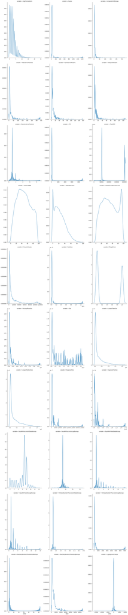

```python
#Plotting distribution
meltdata = pd.melt(data, value_vars=toDescribe)
g = sns.FacetGrid(meltdata, col="variable", col_wrap=3, sharex=False, sharey=False, height=8, aspect=0.7)
g = g.map(sns.distplot, "value", hist=False)
```

#### Correlation matrix

As we have features that can be interpreted, looking for correlation can be a good idea to give a first representation of which IT events can be linked to each other.

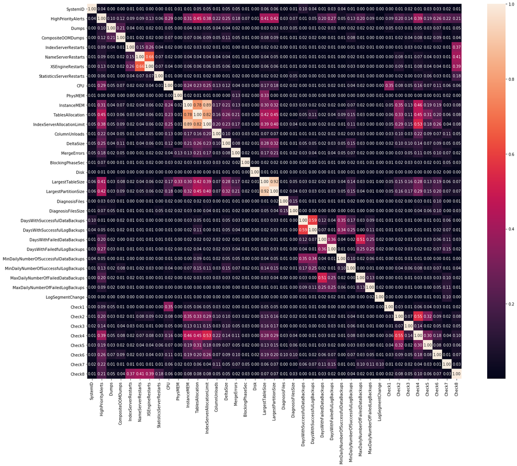

```python
#Correlation matrix
corrmat = abs(data.corr())
f, ax = plt.subplots(figsize=(24, 18))
sns.heatmap(corrmat, vmax=1, square=True, annot=True, annot_kws={'size': 10}, fmt='.2f')
```

For example, it is not surprising that InstanceMEM, IndexServerAllocationLimit and TableAllocation are highly correlated seeing that they all refer to memory aspect of the machine. Similarly they are a little correlated with LargestTableSize and LargestPartitionSize which make sense. Furthermore, for the days of successful/failed log/data backups there exist correlation between them which is again perfectly logic.  
We will use this to combine the features in the following.

For the Check, we notice an high correlation (0.55) between check2 and check4, with both being more or less correlated in the same way with the same features (correlation with InstanceMem, TableAllocation...). Check1 is almost not correlated with any feature except CPU. Other than that, we can say that HighPriorityAlerts is a little correlated with almost all checks.

#### Distribution of Checks

```python
def dfPercentageBinary(dataframe):
    ''' Printing the missing data in the dataframe with the total of missing and the corresponding percentage '''
    df = pd.DataFrame(columns=['0','1'])
    for col in dataframe.columns:
        percentages= dataframe[col].value_counts()/dataframe[col].count()*100
        row = pd.DataFrame([[percentages.loc[0], percentages.loc[1]]], columns = df.columns).rename(index={0:col})
        df = df.append(row)
    return df
```

```python
class_percentages = dfPercentageBinary(data.drop(data.columns.difference(checks), 1))
display(class_percentages)
```

|  | 0 | 1 |
| --- | --- | --- |
| Check1 | 99.376809 | 0.623191 |
| Check2 | 96.661906 | 3.338094 |
| Check3 | 96.939837 | 3.060163 |
| Check4 | 90.089223 | 9.910777 |
| Check5 | 98.777763 | 1.222237 |
| Check6 | 71.187962 | 28.812038 |
| Check7 | 96.940818 | 3.059182 |
| Check8 | 98.982852 | 1.017148 |

The data set is clearly imbalanced with most of the label being 0, which is totally expected for an anomaly detection problem. Still, Check6 differs from the others with almost 30% of label being 1. Anomaly in Check6 are more common.

Let us create a list of of the class weight needed to balanced the data set as well as an average of these weights. The use will depend if we choose a multilabel classifier or not.

```python
class_weight = []
weight_average = {}
weight_0=0
weight_1=1
for check in checks:
    check_dict = {}
    weight_0+= round(50/class_percentages['0'].loc[check],1)
    weight_1+= round(50/class_percentages['1'].loc[check],1)
    check_dict[0] = round(50/class_percentages['0'].loc[check],1)
    check_dict[1] = round(50/class_percentages['1'].loc[check],1)
    class_weight.append(check_dict)

weight_average[0] = round(weight_0/len(checks),2)
weight_average[1] = round(weight_1/len(checks),2)
print("class_weight :", class_weight)
print("weight_average :", weight_average)
```

```
class_weight : [{0: 0.5, 1: 80.2}, {0: 0.5, 1: 15.0}, {0: 0.5, 1: 16.3}, {0: 0.6, 1: 5.0}, {0: 0.5, 1: 40.9}, {0: 0.7, 1: 1.7}, {0: 0.5, 1: 16.3}, {0: 0.5, 1: 49.2}]
weight_average : {0: 0.54, 1: 28.2}
```

### 2. Data Pre-processing

#### Dealing with out of range data

```python
#Considering the out of range samples as missing values
for col in outOfRange:
    data.loc[data[col]>100, col] = np.nan

#Checking
for col in outOfRange:
    print("There are %d samples over the threshold of 100 in %s" %(data.loc[data[col]>100][col].count(), col))
```

```
There are 0 samples over the threshold of 100 in CPU
There are 0 samples over the threshold of 100 in PhysMEM
There are 0 samples over the threshold of 100 in Disk
```

#### Encoding the date and dealing with the SystemID

We need to deal with the date that is the only input not correctly formated. The way the date is given prevents the use of a LabelEncoder. Instead we will just convert the date to the number of seconds since the common date of 1/1/1970 as it is difficult to find the minimum date otherwise. Then we will just remove the minimum everywhere. Maybe using get_dummies would work better for that but we may add a lot of extra columns.

Also we would have liked to use get_dummies for SystemID as there is no notion of order for it. The problem is that it adds many columns, a few thousands, and results in memory error in the tree classifier. For this reasons we did not use it.  
https://medium.com/@guaisang/handling-categorical-features-get-dummies-onehotencoder-and-multicollinearity-f9d473a40417

```python
for i, row in data.iterrows():
    currentDate = datetime.strptime(row.Date, '%d/%m/%Y %H:%M')
    sec = (currentDate-datetime(1970,1,1)).total_seconds()
    data.set_value(i,'Date',sec)

minDate = data["Date"].sort_values()[0]
print("The first date is :", datetime.fromtimestamp(minDate).strftime("%A, %B %d, %Y %I:%M:%S"))
data["Date"] = data["Date"]-minDate
```

```
The first date is : Monday, January 16, 2017 04:04:00
```

#### Splitting the data set

Before more pre-processing (imputing, standardizing...), it is necessary to split the data set. We choose to take 30% of the data for the testing set as we want to have some anomalies in there.

```python
#Separating input from output
y = data[checks]
data.drop(checks, axis=1, inplace=True)

#Splitting our data in training and testing sets, with a choice of 30% of the data for the test
x_train, x_test, y_train, y_test = model_selection.train_test_split(data, y, test_size=0.3, random_state=42)
```

#### Handling missing data

There are different ways of handling missing values, we will use the ones we think the most adapted for each features :

- most common value for categorical features : MergeErrors
- median value for continuous data (with or without outliers) : all the other features except output label
- for the labels, see next part https://towardsdatascience.com/handling-missing-values-in-machine-learning-part-1-dda69d4f88ca

```python
#Finding columns with missing values
missingTrain = x_train.columns[x_train.isnull().any()]
missingTest = x_test.columns[x_test.isnull().any()]

#Filling MergeErrors (categorical values) with the most common values
x_train['MergeErrors'].fillna(x_train['MergeErrors'].mode()[0], inplace=True)
x_test['MergeErrors'].fillna(x_test['MergeErrors'].mode()[0], inplace=True)

#Filling with median values
for col in missingTrain:
    x_train[col].fillna(x_train[col].median(),inplace=True)
for col in missingTest:
    x_test[col].fillna(x_test[col].median(),inplace=True)
```

#### Dealing with the missing checks

If we use several classifier (one for each label) it is not necessary to deal with the missing checks, we will just remove the samples according to each label.  
But in our case we choose for simplicity reason to fill them, we do not have a lot of options to do that. As an anomaly detection problem, it is more likely that the missing are zeros rather than ones, thus we would just fill them with 0.

```python
#At this point only missing values in the checks
y_train.fillna(0,inplace=True)
y_test.fillna(0,inplace=True)
```

#### Features combination and selection

Let us create new features based on IT relations and on what we said before with the correlation matrix.

```python
def addFeatures(X):

    X['NbDumps'] = X['Dumps'] + X['CompositeOOMDumps']

    X['ColAllocation'] = (X['TablesAllocation'] / (X['ColumnUnloads']+1)).astype(np.int64)

    X['TotalDiagnosis'] = X['DiagnosisFiles'] * X['DiagnosisFilesSize']

    X['LargestSize'] = X['LargestTableSize'] + X['LargestPartitionSize']

    X['Restarts'] = X['IndexServerRestarts'] + X['NameServerRestarts'] + X['XSEngineRestarts'] + X['StatisticsServerRestarts']

    X['MEM'] = X['PhysMEM'] + X['InstanceMEM'] + X['TablesAllocation'] + X['IndexServerAllocationLimit']

    X['Hardware'] = X['CPU'] + X['PhysMEM'] + X['Disk']

    X['MaxDailyNumberOfFailed'] = X['MaxDailyNumberOfFailedDataBackups'] + X['MaxDailyNumberOfFailedLogBackups']

    X['MinDailyNumberOfSuccessful'] = X['MinDailyNumberOfSuccessfulLogBackups'] + X['MinDailyNumberOfSuccessfulDataBackups']

    X['DaysSuccessful'] = X['DaysWithSuccessfulLogBackups'] + X['DaysWithSuccessfulDataBackups']

    X['DaysFailed'] = X['DaysWithFailedfulLogBackups'] + X['DaysWithFailedDataBackups']

    return X
```

```python
x_train = addFeatures(x_train)
x_test = addFeatures(x_test)
```

```python
print(x_train.shape)
print(x_test.shape)
```

```
(200921, 43)
(86110, 43)
```

#### Features selection

Using PCA would be a bad idea, we will obtain new columns that we will not be able to interpret !

We can still do some features selection so that we have less features and the interpretation is simpler. https://medium.com/data-design/how-to-not-be-dumb-at-applying-principal-component-analysis-pca-6c14de5b3c9d

> If you are going to apply a correlation robust algorithm (ex: Random Forests, xgboost…): you do not need to care about correlation.

To do this features selection, we will use a similar method as our final evaluation process, we will sum the feature importances given by the Decision Tree (our final model as you will see later) fitted for each label/check.

```python
tree = DecisionTreeClassifier()
feature_importances = np.array([0 for i in range(len(x_train.columns))])
for check in checks:
    tree.fit(x_train, y_train[check])
    feature_importances = np.sum([feature_importances, tree.feature_importances_], axis=0)
```

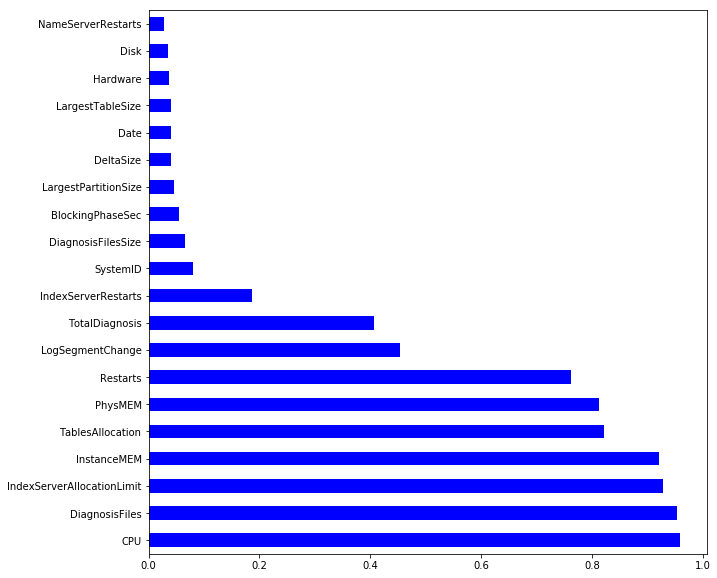

```python
#Plotting most important features in bar
fig, ax1 = plt.subplots(1,1, figsize=(10,10))
features = pd.Series(feature_importances, index=x_train.columns)
features.nlargest(20).plot(kind='barh', colors='b')
```

It is clear from this graph which features are the most important for the model. There is a huge disparity within the top 7 and the rest of the features.

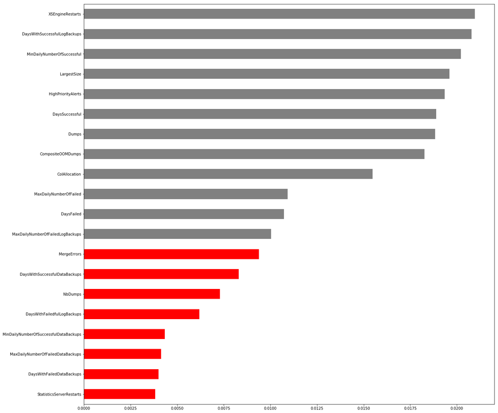

```python
fig, ax1 = plt.subplots(1,1, figsize=(20,20))
threshold = 0.01
smallest_features = features.nsmallest(20)
colors = ['grey' if (x > threshold) else 'red' for x in smallest_features]
smallest_features.plot(kind='barh', colors=colors)
plt.show()
```

We will remove these features visibles in red, they are the less important for the model. It will be easier to interpret the final tree. There is no real need to do that to optimise the computation time of the decision tree as it is pretty fast, but it can be good to interpret the model more easily. Also it may help reduce the time of the Bayesian Rule Sets that takes more time.

We can also see that some of our combined features are more important for the model than the one they came from.

```python
lessImportant = [name for name in smallest_features.index if (smallest_features[name] < threshold)]
print("Dropping :", lessImportant)
x_train = x_train.drop(lessImportant, axis=1)
x_test = x_test.drop(lessImportant, axis=1)
```

```
Dropping : ['StatisticsServerRestarts', 'DaysWithFailedDataBackups', 'MaxDailyNumberOfFailedDataBackups', 'MinDailyNumberOfSuccessfulDataBackups', 'DaysWithFailedfulLogBackups', 'NbDumps', 'DaysWithSuccessfulDataBackups', 'MergeErrors']
```

#### Features selection for decorrelation

Using a decision tree with our features being correlated is not the best solution for intepretability as explained in the quote below. And even if we have many features highly correlated, our tests showed that removing some of them diminish the global score of the model as well as adding in number of nodes ! Therefore we will just remove a few of them :

- LargestSize, LargestTableSize, LargestPartitionSize are all correlated with each other, we will just keep our added feature "LargestSize"
- MinDailyNumberOfSuccessfulLogBakcups and MinDailyNumberOfSuccesful have a correlation almost of one, let us just keep our added feature MinDailyNumberOfSuccesful
- Similarly we will keep our added feature in the pairs (MaxDailyNumberOfFailed, MaxDailyNumberOfFailedLogBackups), (DaysWithSuccessfulLogBackups, DaysSuccessful)
- our added feature MEM is correlated with a lot of other features and we will thus remove it instead of removing all the other features that it came from (better interpretability from the other features)
- let us remove IndexServerAllocationLimit too

https://datascience.stackexchange.com/questions/31402/multicollinearity-in-decision-tree

> Note that single decision trees are intriniscally greedy algorithms - they will fit on the most effective variable they encounter, leaving other plausible variables out. In the case of multicollinearity, this will likely mean that there is a material probability that the algorithm fits not on the 'right' variable, but on a strong variable correlated with the right variable. If you chose a single decision tree because you wanted something that helped you explain the result, the explanation is thus not likely to be completely coherent or satisfactory.

```python
#top correlated features
correlation = x_train.corr().unstack().sort_values().drop_duplicates()
correlation[correlation > 0.75]
```

```
Restarts                              NameServerRestarts                  0.751872
IndexServerAllocationLimit            TablesAllocation                    0.763623
Restarts                              XSEngineRestarts                    0.786286
MEM                                   PhysMEM                             0.821799
TablesAllocation                      MEM                                 0.822342
DaysSuccessful                        DaysWithSuccessfulLogBackups        0.867846
InstanceMEM                           IndexServerAllocationLimit          0.879924
LargestTableSize                      LargestPartitionSize                0.889513
InstanceMEM                           MEM                                 0.940867
IndexServerAllocationLimit            MEM                                 0.946689
LargestTableSize                      LargestSize                         0.968303
LargestPartitionSize                  LargestSize                         0.975444
MinDailyNumberOfSuccessfulLogBackups  MinDailyNumberOfSuccessful          0.999995
MaxDailyNumberOfFailed                MaxDailyNumberOfFailedLogBackups    1.000000
SystemID                              SystemID                            1.000000
dtype: float64
```

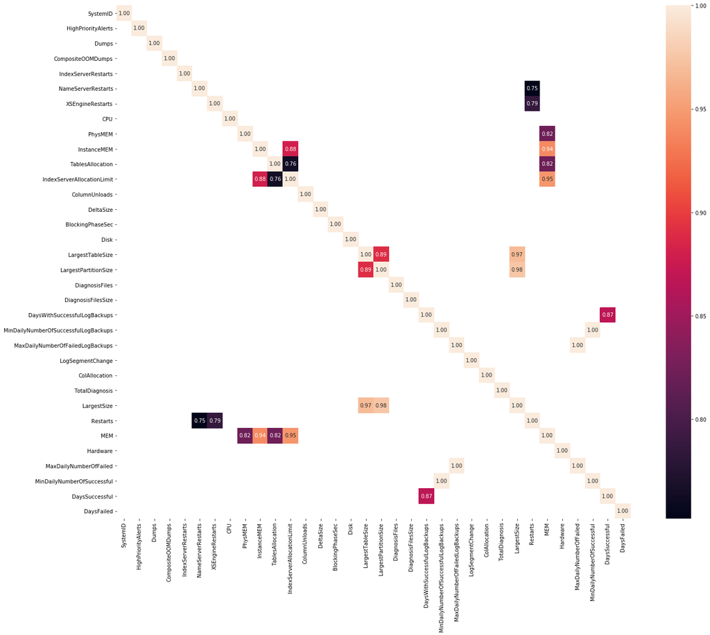

```python
#Correlation matrix
corrmat = abs(x_train.corr())
corrmat = corrmat[corrmat > 0.75]
f, ax = plt.subplots(figsize=(24, 18))
sns.heatmap(corrmat, vmax=1, square=True, annot=True, annot_kws={'size': 10}, fmt='.2f')
```

```python
redundantFeatures = ["Restarts", "DaysWithSuccessfulLogBackups",  "MaxDailyNumberOfFailedLogBackups",
                    "LargestTableSize", "LargestPartitionSize", "MinDailyNumberOfSuccessfulLogBackups", "MEM", "IndexServerAllocationLimit"]
print("Dropping :", redundantFeatures)
x_train = x_train.drop(redundantFeatures, axis=1)
x_test = x_test.drop(redundantFeatures, axis=1)
```

```
Dropping : ['Restarts', 'DaysWithSuccessfulLogBackups', 'MaxDailyNumberOfFailedLogBackups', 'LargestTableSize', 'LargestPartitionSize', 'MinDailyNumberOfSuccessfulLogBackups', 'MEM', 'IndexServerAllocationLimit']
```

```python
#top correlated features
correlation = x_train.corr().unstack().sort_values().drop_duplicates()
correlation[correlation > 0.75]
```

```
SystemID  SystemID    1.0
dtype: float64
```

```python
print("Final x_train shape :", x_train.shape)
print("Final x_test shape :", x_test.shape)

print("Remaining columns :", x_train.columns.tolist())
```

```
Final x_train shape : (200921, 27)
Final x_test shape : (86110, 27)
Remaining columns : ['SystemID', 'Date', 'HighPriorityAlerts', 'Dumps', 'CompositeOOMDumps', 'IndexServerRestarts', 'NameServerRestarts', 'XSEngineRestarts', 'CPU', 'PhysMEM', 'InstanceMEM', 'TablesAllocation', 'ColumnUnloads', 'DeltaSize', 'BlockingPhaseSec', 'Disk', 'DiagnosisFiles', 'DiagnosisFil…
```

#### Standardizing the data

As an anomaly detection problem, outliers are quite important. A standardization that is not robust to them seems to be a good choice, if we chose to standardize we would use the StandardScaler instead of the RobustScaler. Every feature here can be scaled as we already dealt with the Date and the SystemID. Yet, as our model is a decision tree, it is not necessary to standardize the data for now. Keeping it this way is even better for interpretability purpose.

### 3. Model Selection

#### 3.1 Choice of a (less interpretable) model

References :

- https://scikit-learn.org/stable/modules/multiclass.html

#### Multi-label classification

Using a multi-label classfier would be great as :

- it avoids optimizing 8 classifiers (one for each check) individually.
- it allows to predict properties that are not mutually exclusive. Indeed it is possible that some anomalies are related in some ways.

Yet it has the drawback of :

- being less flexible
- making the interpretation more complicated
- needing to deal with the missing values in the checks

#### One classification per label

We can say that the advantages of this method are the opposite of the drawbacks of the multi-label classification, and vice-versa.

#### Which classifier

**Decision Tree** : We will use Decision Tree as it allows for more interpretability which is a primary goal of this anomaly detection problem. It is not needed to do standardization of the data, which makes the reading more intuitive to a real IT engineer. Yet a problem of decisions trees with regard to our problem is that :

> Decision tree learners create biased trees if some classes dominate. It is therefore recommended to balance the dataset prior to fitting with the decision tree.

Still it is possible to give more weight to one class which should help solve this problem.

**MLP classifier** : It seems that using a MLP classifier would be the best choice as we have a huge number of samples but it lacks the interpretability we really want in this AD problem this is why we won't use it.

**LabelPropagation/LabelSpreading classifier** : These two classifiers are for semi-supervied learning, they would be great to avoid dealing with the missing values in the check.

**Conclusion** : for the interpretability we will train a decision tree. We will do a classification per label in order to make the interpretation simpler for each anomaly (it can be useful to try to give a name for each check) as well as computing the f1_score. Still, for time reason we will do only one classifier, i.e we will tune only one classifier that gives the best average f1_score. Furthermore we will not try to remove the unwanted samples (with missing labels) so we could have do that accordingly to each studied label, we will keep the filling with zeros we made.

#### 3.2 Interpretable Models

For the interpretable model, we will use a Bayesian Rule Sets (BRS) model. According to the paper, this "method has a major advantage over classical associative classification methods and decision trees in that it does not greedily grow the model", so we will be able to check that with our decision tree model later on.

We will need to process the data so that the parser can recognize the data :

- X has to be a pandas DataFrame : already good
- all the column names can not contain '_' or '<' and cannot be pure numbers : already good
- the categorical data should be represented in string : we need to treat the "SystemID" column
- "y" has to be a numpy.ndarray : we will need to process each label/check independtly and use .values

We will make a copy of the previous processing data so that we can still use it later as it is for the decision tree. This model takes a lot of time and leads to memory error when use with every data. That's why we will only process a small subset of the data.

```python
#Taking a subset of the data
n_split = 30
n_train = len(x_train)
x_train_bay = x_train[:int(n_train/n_split)]
y_train_bay = y_train[:int(n_train/n_split)]

n_test = len(x_test)
x_test_bay = x_test[:int(n_test/n_split)]
y_test_bay = y_test[:int(n_test/n_split)]

#Treating the categorical data
x_train_bay["SystemID"] = x_train_bay["SystemID"].astype(str)
x_test_bay["SystemID"] = x_test_bay["SystemID"].astype(str)

#Treating the labels as True/False values
y_train_bay = (y_train_bay==1)
y_test_bay = (y_test_bay==1)
```

### 4. Parameter Optimisation

#### 4.1 Optimisation of the Decision Tree

References :

- https://medium.com/machine-learning-101/chapter-3-decision-tree-classifier-coding-ae7df4284e99
- https://medium.com/@mohtedibf/indepth-parameter-tuning-for-decision-tree-6753118a03c3

These are the parameters we can try to tune for a decision tree :

- max_depth : for interpretability choice, we could try to fix the max depth of the tree, it is also useful for avoiding overfitting. We will try to tune this parameter.

  > This indicates how deep the tree can be. The deeper the tree, the more splits it has and it captures more information about the data. The model can overfit for large depth values.
- min_samples_split : as we do not have a lot of samples for the anomalies, we shall not put a too high minimum sample split, similarly if we chose a too high minimum sample split it could be responsible for underfitting.

  > This can vary between considering at least one sample at each node to considering all of the samples at each node. When we increase this parameter, the tree becomes more constrained as it has to consider more samples at each node.
- max_features : we will try to tune this parameter.

  > The number of features to consider when looking for the best split.
- criterion : preliminary experiments show that 'entropy' give better results and a less deep tree, thus a more easily interpretable tree. We will stay with this choice and not tune it.

  > In theory part we learned that one of good spliting decision is to take one that provides the best information gain. Criteria for sklearn can be gini or entropy( for information gain). The function to measure the quality of a split. Supported criteria are “gini” for the Gini impurity and “entropy” for the information gain.
- min_samples_leaf : we will not tune this parameter as it does not seem to have a huge influence except causing underfitting when raising it.

  > The minimum number of samples required to be at a leaf node. This parameter is similar to min_samples_splits, however, this describe the minimum number of samples at the leafs, the base of the tree. Increasing this value may cause underfitting.
- class_weight : to solve the imbalanced data issue, we will tune it but with still trying our "weight_average" defined earlier.

Let us define for a function to evaluate our model, so goal being to optimize a tree that works for all labels individually.

```python
def evaluateTree(tree, x_test, y_test):
    ''' return the mean of the f1_score and the mean of the number of nodes in the tree'''
    f1_score=0
    n_nodes=0
    for check in checks:
        tree.fit(x_train, y_train[check])
        n_nodes+= tree.tree_.node_count
        y_pred = tree.predict(x_test)
        f1_score+= metrics.f1_score(y_test[check], y_pred, average='macro')
    return f1_score/len(checks), n_nodes/len(checks)
```

```python
print("We had a class weight average :", weight_average)
```

```
We had a class weight average : {0: 0.54, 1: 28.2}
```

```python
# Define the hyperparameters
hyperparameters = {
    'min_split': [2, 5, 8],
    'max_depth': [25, 50, 75],
    'max_feat': [10, 15, 20],
    'class_weight': [weight_average, {0:1, 1:100}, {0:1, 1:150}]
}

# Compute all combinations
parameter_grid = list(model_selection.ParameterGrid(hyperparameters))
resultsDF = pd.DataFrame(columns=['min_split', 'max_depth', 'max_feat', 'avg_f1', 'avg_nodes'])
for p in parameter_grid:
    tree = DecisionTreeClassifier(random_state=1, criterion="entropy", class_weight = p['class_weight'],
                                 min_samples_split=p['min_split'], max_depth=p['max_depth'], max_features=p['max_feat'])
    avg_f1, avg_nodes = evaluateTree(tree, x_test, y_test)
    p['avg_f1']=avg_f1
    p['avg_nodes']=avg_nodes
    resultsDF = resultsDF.append(p, ignore_index=True)
```

```python
display(resultsDF.sort_values(by=['avg_f1', 'avg_nodes'], ascending=[False,True]).head())
```

|  | min_split | max_depth | max_feat | avg_f1 | avg_nodes | class_weight |
| --- | --- | --- | --- | --- | --- | --- |
| 10 | 5 | 50 | 10 | 0.950453 | 2223.25 | {0: 0.54, 1: 28.2} |
| 19 | 5 | 75 | 10 | 0.950453 | 2223.25 | {0: 0.54, 1: 28.2} |
| 51 | 2 | 75 | 20 | 0.947959 | 2178.00 | {0: 1, 1: 100} |
| 39 | 2 | 50 | 15 | 0.947195 | 2223.50 | {0: 1, 1: 100} |
| 36 | 2 | 50 | 10 | 0.947174 | 2453.50 | {0: 1, 1: 100} |

#### 4.2 Optimisation of the Bayesian rule sets

As this model takes a lot of fitting time and leads to a lot of problem (kernel stops due to memory error) even with this small subset of data, we will not try to tune it like the decision tree. Instead we tried to tune it manually, the results of the different tests are not shown in the final notebook.  
Here are the parameters for this model :

- 'max_iter' : we will limit it so that it does not take too much time.
- 'method' : we will keep the 'forest' method as the other one 'fpgrowth' is "not a good method as it will have memory issue if there are potentially many rules". Furthermore with our model the number of rules in the preliminary tests are really reasonables (less than 10) so we will not tune it, it is possible that it is due to the fact that we only take a small subset of the whole dataset.
- 'propose_threshold' : default 0.1, threshold for a proposal to be accepted, when we try to raises it provokes a memory error.
- 'maxlen' : default 3, the maximum number of items in a rule

We will use a similar tool evaluation as the one we used for decision tree. Still at the end it will not be possible to compare which is the best model or which is the simpler to interpret as we do not use the same amount of data.

```python
#Removing print for the fit of the model
@contextmanager
def suppress_stdout():
    with open(os.devnull, "w") as devnull:
        old_stdout = sys.stdout
        sys.stdout = devnull
        try:
            yield
        finally:
            sys.stdout = old_stdout

def evaluateModel(model, x_test_bay, y_test_bay):
    ''' return the mean of the f1_score'''
    f1_score=0
    for check in checks:
        with suppress_stdout():
            model.fit(x_train_bay, y_train_bay[check].values)
        y_pred = model.predict(x_test_bay)
        f1_score+= metrics.f1_score(y_test_bay[check].values, y_pred, average='macro')
    return f1_score/len(checks)
```

```python
model = rs.BayesianRuleSet(method='forest', max_iter=5, maxlen=3, propose_threshold=0.1)
avg_f1_score = evaluateModel(model, x_test_bay, y_test_bay)
print("Avg f1_score =", avg_f1_score)
```

```
Avg f1_score = 0.6428082006004867
```

### 5. Model Evaluation

#### 5.1 Evaluation of the Decision Tree

#### Final model

```python
tree = DecisionTreeClassifier(random_state=1, criterion="entropy", class_weight = weight_average,
                              min_samples_split=5, max_depth=50, max_features=10)
```

#### Average f1_score

```python
f1_score = evaluateTree(tree, x_test, y_test)[0]
print("Final f1_score :", f1_score)
```

```
Final f1_score : 0.9504529991800668
```

We evaluated the model using the average of the f1_score for each label, this score is quite good !

#### Confusion matrices

We can also evaluate it by plotting the confusion matrices.  
https://scikit-learn.org/stable/auto_examples/model_selection/plot_confusion_matrix.html#sphx-glr-auto-examples-model-selection-plot-confusion-matrix-py

```python
def getConfusionMatrices(model, x_test, y_test):
    all_matrices = []
    errors = 0
    for check in checks:
        tree.fit(x_train, y_train[check].values)
        y_pred = model.predict(x_test)
        confusion_matrix = metrics.confusion_matrix(y_test[check], y_pred)
        tn, fp, fn, tp = confusion_matrix.ravel()
        df = pd.DataFrame(columns = ["Real 0", "Real 1"])
        row1 = pd.DataFrame([[tn, fn]], columns = df.columns).rename(index={0:"Predicted 0"})
        row2 = pd.DataFrame([[fp, tp]], columns = df.columns).rename(index={0:"Predicted 1"})
        errors+= fp + fn
        df = df.append(row1).append(row2)
        all_matrices.append(df)
    errors = errors/(len(y_test)*8)*100
    return all_matrices, errors
```

```python
all_matrices, errors = getConfusionMatrices(tree, x_test, y_test)
```

```python
#Plotting the confusion matrices for each check
def plotConfusionMatrices(normalize=False):
    fig, ((ax1, ax2, ax3, ax4), (ax5, ax6, ax7, ax8)) = plt.subplots(2,4,figsize=(10,8))
    axes = [ax1, ax2, ax3, ax4, ax5, ax6, ax7, ax8]
    titles = checks
    cmap=plt.cm.Blues
    for i,matrice in enumerate(all_matrices):
        cm= [[matrice.values[i][j] for j in range(matrice.shape[1])] for i in range(matrice.shape[0])]
        cm=np.array(cm)
        # Only use the labels that appear in the data
        classes = ["0", "1"]

        #Normalize
        if normalize:
            cm = cm.astype('float') / cm.sum(axis=1)[:, np.newaxis]
        ax = axes[i]
        im = ax.imshow(cm.reshape(cm.shape[0], cm.shape[1]), interpolation='nearest', cmap=cmap)
        ax.figure.colorbar(im, ax=ax)
        # We want to show all ticks...
        ax.set(xticks=np.arange(cm.shape[1]),
               yticks=np.arange(cm.shape[0]),
               # ... and label them with the respective list entries
               xticklabels=classes, yticklabels=classes,
               title=titles[i],
               ylabel='Predicted label',
               xlabel='True label')

        # Rotate the tick labels and set their alignment.
        plt.setp(ax.get_xticklabels(), rotation=45, ha="right",
                 rotation_mode="anchor")

        # Loop over data dimensions and create text annotations.
        fmt = '.2f' if normalize else 'd'
        thresh = cm.max() / 2.
        for i in range(cm.shape[0]):
            for j in range(cm.shape[1]):
                ax.text(j, i, format(cm[i, j], fmt),
                        ha="center", va="center",
                        color="white" if cm[i, j] > thresh else "black")
        fig.tight_layout()
    plt.show()
```

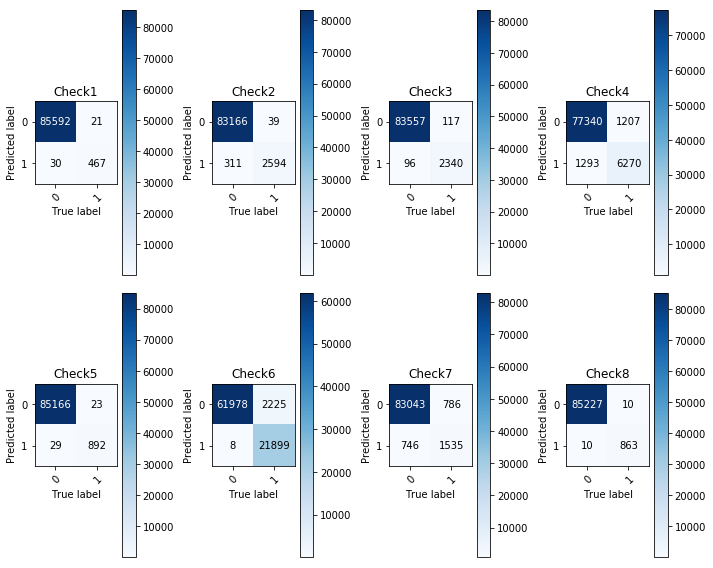

```python
plotConfusionMatrices(False)
```

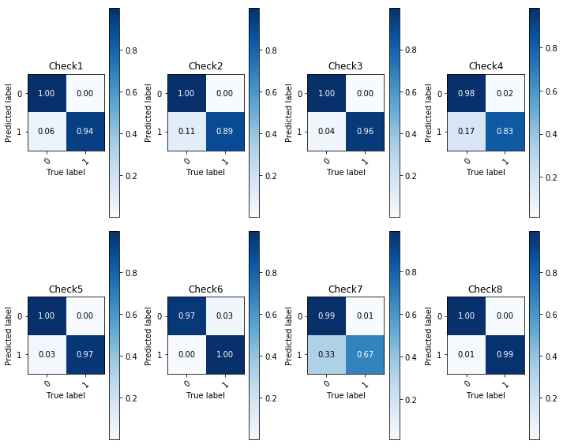

```python
plotConfusionMatrices(True)
```

#### Interpretability

Then we can "evaluate" the model in term of interpretability. The decision tree is an interpretable model.

```python
avg_nodes = evaluateTree(tree, x_test, y_test)[1]
print("Final avg_score :", avg_nodes)
```

```
Final avg_score : 2223.25
```

It may not be that easy to interpret this tree with this huge number of nodes. We will try to interpret it with a specific check in the last part.

#### 5.2 Evaluation of the Bayesian Rule Set

Let us now do the same for the BRS model.

#### Average f1_score

```python
print("Avg f1_score =", avg_f1_score)
```

```
Avg f1_score = 0.6428082006004867
```

#### Confusion matrices

```python
all_matrices, errors = getConfusionMatrices(model, x_test_bay, y_test_bay)
```

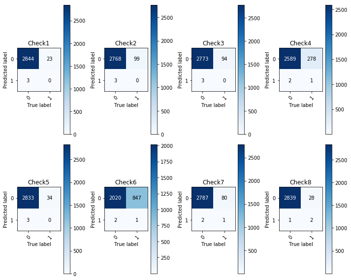

```python
plotConfusionMatrices(False)
```

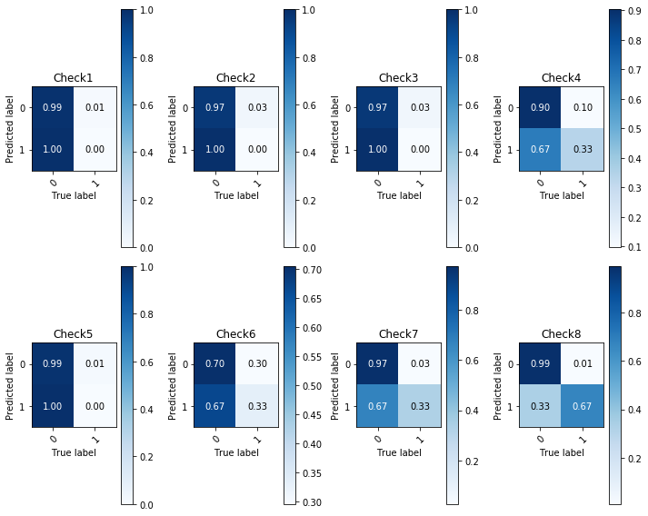

```python
plotConfusionMatrices(True)
```

Due to the poor amount of anomalies in this subset of the data and the impossiblity to train correclty the model, anomalies are almost always predicted as non-anomaly.

#### Interpretability

For the interpretability, we will try to display the rules for a specific check in the following part.

### 6. Giving meaningful name to one check

In this part we will try to interpret the tree and the rules we get when the models are trained for check6. We choose to do with this one as there were around 30% of anomalies for this check and the Decision Tree works very well on it, thus making the rules more accurate and maybe less numerous.

```python
check = "Check6"
```

#### Using the Decision Tree

Let us define a tool to try to describe the tree generated for this check. Then we will compare with the rules given by BRS. The following methods are adapted from https://scikit-learn.org/stable/auto_examples/tree/plot_unveil_tree_structure.html#sphx-glr-auto-examples-tree-plot-unveil-tree-structure-py

```python
tree.fit(x_train, y_train[check])
```

```
DecisionTreeClassifier(class_weight={0: 0.54, 1: 28.2}, criterion='entropy',
                       max_depth=50, max_features=10, max_leaf_nodes=None,
                       min_impurity_decrease=0.0, min_impurity_split=None,
                       min_samples_leaf=1, min_samples_split=5,
                       min_weight_fraction_leaf=0.0, presort=False,
                       random_state=1, splitter='best')
```

```python
def interpretTree(tree, columns, nodes_displayed=None):
    # The decision estimator has an attribute called tree_  which stores the entire
    # tree structure and allows access to low level attributes. The binary tree
    # tree_ is represented as a number of parallel arrays. The i-th element of each
    # array holds information about the node `i`. Node 0 is the tree's root. NOTE:
    # Some of the arrays only apply to either leaves or split nodes, resp. In this
    # case the values of nodes of the other type are arbitrary!
    #
    # Among those arrays, we have:
    #   - left_child, id of the left child of the node
    #   - right_child, id of the right child of the node
    #   - feature, feature used for splitting the node
    #   - threshold, threshold value at the node
    #

    # Using those arrays, we can parse the tree structure:
    n_nodes = tree.tree_.node_count

    if nodes_displayed==None:
        nodes_displayed=n_nodes
    children_left = tree.tree_.children_left
    children_right = tree.tree_.children_right
    feature = tree.tree_.feature
    threshold = tree.tree_.threshold


    # The tree structure can be traversed to compute various properties such
    # as the depth of each node and whether or not it is a leaf.
    node_depth = np.zeros(shape=n_nodes, dtype=np.int64)
    is_leaves = np.zeros(shape=n_nodes, dtype=bool)
    stack = [(0, -1)]  # seed is the root node id and its parent depth
    while len(stack) > 0:
        node_id, parent_depth = stack.pop()
        node_depth[node_id] = parent_depth + 1

        # If we have a test node
        if (children_left[node_id] != children_right[node_id]):
            stack.append((children_left[node_id], parent_depth + 1))
            stack.append((children_right[node_id], parent_depth + 1))
        else:
            is_leaves[node_id] = True

    print("The binary tree structure has %s nodes and has "
          "the following tree structure:"
          % n_nodes)
    for i in range(nodes_displayed):
        if is_leaves[i]:
            print("%snode=%s leaf node." % (node_depth[i] * "\t", i))
        else:
            print("%snode=%s test node: go to node %s if %s <= %s else to "
                  "node %s."
                  % (node_depth[i] * "\t",
                     i,
                     children_left[i],
                     columns[feature[i]],
                     round(threshold[i],3),
                     children_right[i],
                     ))
    print()
```

```python
def getRulesForSample(tree, sample_id, x):
    # First let's retrieve the decision path of each sample. The decision_path
    # method allows to retrieve the node indicator functions. A non zero element of
    # indicator matrix at the position (i, j) indicates that the sample i goes
    # through the node j.

    node_indicator = tree.decision_path(x_test)
    feature = tree.tree_.feature
    threshold = tree.tree_.threshold
    # Similarly, we can also have the leaves ids reached by each sample.

    leave_id = tree.apply(x_test)

    # Now, it's possible to get the tests that were used to predict a sample or
    # a group of samples. First, let's make it for the sample.

    node_index = node_indicator.indices[node_indicator.indptr[sample_id]:
                                        node_indicator.indptr[sample_id + 1]]

    print('Rules used to predict sample %s: ' % sample_id)
    for node_id in node_index:
        if leave_id[sample_id] == node_id:
            continue

        if (x.iloc[sample_id, feature[node_id]] <= threshold[node_id]):
            threshold_sign = "<="
        else:
            threshold_sign = ">"

        print("decision id node %s : (%s (= %s) %s %s)"
              % (node_id,
                 x.columns[feature[node_id]],
                 x.iloc[sample_id, feature[node_id]],
                 threshold_sign,
                 threshold[node_id]))
```

```python
interpretTree(tree, x_train.columns, 10)
```

```
The binary tree structure has 2201 nodes and has the following tree structure:
node=0 test node: go to node 1 if DiagnosisFilesSize <= 731011520.0 else to node 12.
	node=1 test node: go to node 2 if SystemID <= 50.5 else to node 9.
		node=2 test node: go to node 3 if DiagnosisFilesSize <= 407435408.0 else to node 6.
			node=3 test node: go to node 4 if DiagnosisFiles <= 153.0 else to node 5.
				node=4 leaf node.
				node=5 leaf node.
			node=6 test node: go to node 7 if DiagnosisFiles <= 150.5 else to node 8.
				node=7 leaf node.
				node=8 leaf node.
		node=9 test node: go to node 10 if DiagnosisFiles <= 150.5 else to node 11.
```

With so many nodes it will not be possible to interpret the tree to give a name to the check. But we can try using the other methods to get the rules specifics for some samples.

```python
#finding some samples id with anomaly
samples_ids = []
i=0
while len(samples_ids)<100:
    if y_train[check].iloc[i]==1:
        samples_ids.append(i)
    i+=1
```

For a lot of these samples the rules are only based on SystemID, DiagnosisFile etc. that we cannot interpret to give a name to the check. But when trying with more samples we can find other information, but it is still too hard to give a name.

```python
getRulesForSample(tree, samples_ids[0], x_train)
print()
getRulesForSample(tree, samples_ids[1], x_train)
print()
getRulesForSample(tree, samples_ids[3], x_train)
print()
getRulesForSample(tree, samples_ids[7], x_train)
```

```
Rules used to predict sample 2:
decision id node 0 : (DiagnosisFilesSize (= 1957066180.0) > 731011520.0)
decision id node 12 : (DiagnosisFiles (= 279.0) > 150.5)
decision id node 13 : (DiagnosisFilesSize (= 1957066180.0) > 734481824.0)
decision id node 2123 : (BlockingPhaseSec (= 20.0) > 6.5)
decision id node 2129 : (DiagnosisFilesSize (= 1957066180.0) <= 6369520640.0)

Rules used to predict sample 3:
decision id node 0 : (DiagnosisFilesSize (= 1562083712.0) > 731011520.0)
decision id node 1 : (SystemID (= 821) > 50.5)
decision id node 9 : (DiagnosisFiles (= 328.0) > 150.5)

Rules used to predict sample 11:
decision id node 0 : (DiagnosisFilesSize (= 2372084709.0) > 731011520.0)
decision id node 12 : (DiagnosisFiles (= 746.0) > 150.5)
decision id node 2132 : (LargestSize (= 146867186.0) <= 175333744.0)
decision id node 2134 : (ColAllocation (= 14) > 0.5)
decision id node 2176 : (DaysSuccessful (= 15) <= 17.5)
decision id node 2177 : (DiagnosisFilesSize (= 2372084709.0) <= 12009423872.0)
decision id node 2178 : (MinDailyNumberOfSuccessful (= 103) > 10.5)

Rules used to predict sample 22:
decision id node 0 : (DiagnosisFilesSize (= 8332384481.0) > 731011520.0)
decision id node 12 : (DiagnosisFiles (= 598.0) > 150.5)
decision id node 2132 : (LargestSize (= 4257553872.0) > 175333744.0)
decision id node 2134 : (ColAllocation (= 66) > 0.5)
decision id node 2176 : (DaysSuccessful (= 11) <= 17.5)
decision id node 2177 : (DiagnosisFilesSize (= 8332384481.0) <= 12009423872.0)
decision id node 2178 : (MinDailyNumberOfSuccessful (= 212) > 10.5)
```

```python
def getCommonNode(tree, sample_ids, x):
    # For a group of samples, we have the following common node.
    node_indicator = tree.decision_path(x)

    common_nodes = (node_indicator.toarray()[sample_ids].sum(axis=0) ==
                    len(sample_ids))
    n_nodes = tree.tree_.node_count
    common_node_id = np.arange(n_nodes)[common_nodes]
    feature = tree.tree_.feature
    threshold = tree.tree_.threshold
    print("The samples are based on nodes that have the following rules :")
    for node_id in common_node_id:
        if (x.iloc[sample_ids[0], feature[node_id]] <= threshold[node_id]):
            threshold_sign = "<="
        else:
            threshold_sign = ">"

        print("%s %s %s"
              % (x.columns[feature[node_id]],
                 threshold_sign,
                 threshold[node_id]))
```

```python
getCommonNode(tree, [11,22], x_train)
```

```
The samples are based on nodes that have the following rules :
DiagnosisFilesSize > 731011520.0)
DiagnosisFiles > 150.5)
LargestSize <= 175333744.0)
```

This method is not efficient to interpret the model as there are too many nodes in this tree.

#### Using the BSR model

```python
model = rs.BayesianRuleSet(method='forest', max_iter=10, maxlen=3, propose_threshold=0.1)
model.fit(x_train_bay, y_train_bay[check].values)
```

```
** chain = 1, max at iter = 0 **
 accuracy = 0.9656562639988054, TP = 1663,FP = 20, TN = 4804, FN = 210
 old is -999999999.9, pt_new is -1017.4439329919855, prior_ChsRules=-30.894868534058332, likelihood_1 = -110.1480853057135, likelihood_2 = -876.4009791522137

['150.0<=DiagnosisFiles', '17681585036.0<=TotalDiagnosis', 'SystemID_64_neg']
[195]
```

```python
model.print_rules(model.predicted_rules)
```

```
['150.0<=DiagnosisFiles', '17681585036.0<=TotalDiagnosis', 'SystemID_64_neg']
```

Again the rules are not explicit enough to give a name to the check. Maybe if we wanted to do that we should remove all features that are not clearly intepretable like the SystemID or the DiagnosisFiles in the pre-processing part.